# Self-Driving Car Engineer Nanodegree

## Project 3: Build a Traffic Sign Recognition Classifier

Udacity Project 3 - Building a CNN with tensorflow to classify traffic signs of the size 32x32x3.

## Step 0: Load The Data

```python
# Load pickled data
import pickle

training_file = "traffic-signs-data/train.p"
validation_file= "traffic-signs-data/valid.p"
testing_file = "traffic-signs-data/test.p"

with open(training_file, mode='rb') as f:
    train = pickle.load(f)
with open(validation_file, mode='rb') as f:
    valid = pickle.load(f)
with open(testing_file, mode='rb') as f:
    test = pickle.load(f)

X_train, y_train = train['features'], train['labels']
X_valid, y_valid = valid['features'], valid['labels']
X_test, y_test = test['features'], test['labels']
```

## Step 1: Dataset Summary & Exploration

The pickled data is a dictionary with 4 key/value pairs:

- `'features'` is a 4D array containing raw pixel data of the traffic sign images, (num examples, width, height, channels).
- `'labels'` is a 1D array containing the label/class id of the traffic sign. The file `signnames.csv` contains id -> name mappings for each id.
- `'sizes'` is a list containing tuples, (width, height) representing the original width and height the image.
- `'coords'` is a list containing tuples, (x1, y1, x2, y2) representing coordinates of a bounding box around the sign in the image. **THESE COORDINATES ASSUME THE ORIGINAL IMAGE. THE PICKLED DATA CONTAINS RESIZED VERSIONS (32 by 32) OF THESE IMAGES**

### Provide a Basic Summary of the Data Set Using Python, Numpy and/or Pandas

```python
import numpy as np

# Number of training examples
n_train = X_train.shape[0]

# Number of validation examples
n_validation = X_valid.shape[0]

# Number of testing examples.
n_test = X_test.shape[0]

# What's the shape of an traffic sign image?
image_shape = X_train.shape[1:]

# How many unique classes/labels there are in the dataset.
n_classes = np.max(y_train) + 1

print("Number of training examples =", n_train)
print("Number of validation examples =", n_validation)
print("Number of testing examples =", n_test)
print("Image data shape =", image_shape)
print("Number of classes =", n_classes)
```

```
Number of training examples = 34799
Number of validation examples = 4410
Number of testing examples = 12630
Image data shape = (32, 32, 3)
Number of classes = 43
```

### Include an exploratory visualization of the dataset

Visualization of the German Traffic Signs Dataset using the pickled file(s).

#### Data Histogram

The data is not equally distributed between all classes. Some are more rare than others and will be therefore more difficult to train.

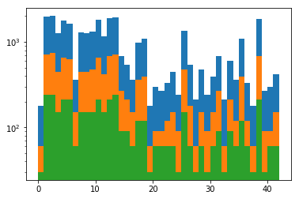

```python
import matplotlib.pyplot as plt
%matplotlib inline

# create histograms for train, validation and test data.
plt.hist(y_train, bins=np.max(y_train))
plt.hist(y_test, bins=np.max(y_test))
plt.hist(y_valid, bins=np.max(y_valid))
plt.yscale("log")
plt.show()
```

#### Show all the different classes available in the dataset

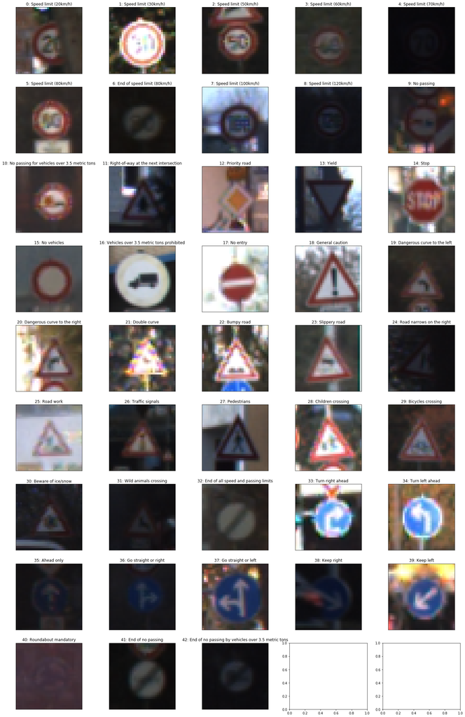

```python
import pandas as pd

signnames = pd.read_csv("signnames.csv").SignName

num_of_rows = int((np.max(y_train)+1)/5+.9) # max+1 = num of classes; divided by 5 and +.9 for rounding up
f, axarr = plt.subplots(num_of_rows, 5, figsize=(25, 40))

for i in range(np.max(y_train)+1):
    axarr[int(i/5), i%5].imshow(X_valid[np.where(y_valid == i)[0][0]])
    axarr[int(i/5), i%5].set_title(str(i) + ": " + signnames[i])
    axarr[int(i/5), i%5].get_xaxis().set_visible(False)
    axarr[int(i/5), i%5].get_yaxis().set_visible(False)
```

## Step 2: Design and Test a Model Architecture

Design and implement a deep learning model that learns to recognize traffic signs. Train and test your model on the [German Traffic Sign Dataset](http://benchmark.ini.rub.de/?section=gtsrb&subsection=dataset).

The LeNet-5 implementation is a solid starting point.

To meet specifications, the validation set accuracy will need to be at least 0.93. It is possible to get an even higher accuracy, but 0.93 is the minimum for a successful project submission.

There are various aspects to consider when thinking about this problem:

- Neural network architecture (is the network over or underfitting?)
- Play around preprocessing techniques (normalization, rgb to grayscale, etc)
- Number of examples per label (some have more than others).
- Generate fake data.

Here is an example of a [published baseline model on this problem](http://yann.lecun.com/exdb/publis/pdf/sermanet-ijcnn-11.pdf). It's not required to be familiar with the approach used in the paper but, it's good practice to try to read papers like these.

### Pre-process the Data Set (normalization, grayscale, etc.)

Minimally, the image data should be normalized so that the data has mean zero and equal variance. For image data, `(pixel - 128)/ 128` is a quick way to approximately normalize the data and can be used in this project.

```python
# Normalize all the data

def normalize(data):
    data = (data - 128.)/128
    return data

if np.max(X_train) > 1:
    X_train = normalize(X_train)
    X_valid = normalize(X_valid)
    X_test = normalize(X_test)
    print("Normalization Successful")
else:
    print("Data already normalized")
```

```
Normalization Successful
```

### Model Architecture

```python
# CNN model architecture

import tensorflow as tf
from sklearn.utils import shuffle
from tensorflow.contrib.layers import flatten

EPOCHS = 50 #
BATCH_SIZE = 2000
learning_rate = 0.002
dropout_training = 0.6 # Dropout to avoid overfitting

def CNN(x):
    mu = 0
    sigma = 0.1

    # Layer 1: Convolutional. Input = 32x32x3
    conv1_W = tf.Variable(tf.truncated_normal(shape=(3, 3, 3, 8), mean = mu, stddev = sigma))
    #Shape: Kernel, Kernel, Input Depth, Output Depth
    conv1_b = tf.Variable(tf.zeros(8))
    conv1   = tf.nn.conv2d(x, conv1_W, strides=[1, 1, 1, 1], padding='SAME') + conv1_b
    conv1 = tf.nn.relu(conv1)

    # Layer 2: Convolutional. Input 32x32x8
    conv2_W = tf.Variable(tf.truncated_normal(shape=(3, 3, 8, 8), mean = mu, stddev = sigma))
    conv2_b = tf.Variable(tf.zeros(8))
    conv2   = tf.nn.conv2d(conv1, conv2_W, strides=[1, 1, 1, 1], padding='SAME') + conv2_b
    conv2 = tf.nn.relu(conv2)

    # Pooling. Input = 32x32x8
    conv2 = tf.nn.max_pool(conv2, ksize=[1, 2, 2, 1], strides=[1, 2, 2, 1], padding='VALID')
    conv2 = tf.nn.dropout(conv2, dropout)

    # Layer 3: Convolutional. Input 16x16x8
    conv3_W = tf.Variable(tf.truncated_normal(shape=(3, 3, 8, 16), mean = mu, stddev = sigma))
    conv3_b = tf.Variable(tf.zeros(16))
    conv3   = tf.nn.conv2d(conv2, conv3_W, strides=[1, 1, 1, 1], padding='SAME') + conv3_b
    conv3 = tf.nn.relu(conv3)

    # Layer 4: Convolutional. Input 16x16x16
    conv4_W = tf.Variable(tf.truncated_normal(shape=(3, 3, 16, 16), mean = mu, stddev = sigma))
    conv4_b = tf.Variable(tf.zeros(16))
    conv4   = tf.nn.conv2d(conv3, conv4_W, strides=[1, 1, 1, 1], padding='SAME') + conv4_b
    conv4 = tf.nn.relu(conv4)

    # Pooling. Input = 16x16x16
    conv4 = tf.nn.max_pool(conv4, ksize=[1, 2, 2, 1], strides=[1, 2, 2, 1], padding='VALID')
    conv4 = tf.nn.dropout(conv4, dropout)



    fc0_0 = flatten(conv2) # 16x16x8 = 2048
    fc0_1 = flatten(conv4) # 8x8x16 = 1024

    fc0 = tf.concat([fc0_0, fc0_1], 1)


    # Layer 5: Fully Connected. Input = 3072
    fc1_W = tf.Variable(tf.truncated_normal(shape=(3072, 1024), mean = mu, stddev = sigma))
    fc1_b = tf.Variable(tf.zeros(1024))
    fc1   = tf.matmul(fc0, fc1_W) + fc1_b
    fc1 = tf.nn.batch_normalization(fc1, mean=0, variance=0.2, offset=None, scale=None, variance_epsilon=1e-5)
    fc1    = tf.nn.relu(fc1)
    fc1 = tf.nn.dropout(fc1, dropout)

    # Layer 6: Fully Connected. Input = 1024
    fc2_W  = tf.Variable(tf.truncated_normal(shape=(1024, 256), mean = mu, stddev = sigma))
    fc2_b  = tf.Variable(tf.zeros(256))
    fc2    = tf.matmul(fc1, fc2_W) + fc2_b
    fc2 = tf.nn.batch_normalization(fc2, mean=0, variance=0.2, offset=None, scale=None, variance_epsilon=1e-5)
    fc2    = tf.nn.relu(fc2)
    fc2 = tf.nn.dropout(fc2, dropout)

    # Layer 7: Fully Connected. Input = 256. Output = 43.
    fc3_W  = tf.Variable(tf.truncated_normal(shape=(256, 43), mean = mu, stddev = sigma))
    fc3_b  = tf.Variable(tf.zeros(43))
    logits = tf.matmul(fc2, fc3_W) + fc3_b

    return logits
```

### Train, Validate and Test the Model

A validation set can be used to assess how well the model is performing. A low accuracy on the training and validation sets imply underfitting. A high accuracy on the training set but low accuracy on the validation set implies overfitting.

```python
### Train your model here.
### Calculate and report the accuracy on the training and validation set.
### Once a final model architecture is selected,
### the accuracy on the test set should be calculated and reported as well.
### Feel free to use as many code cells as needed.

x = tf.placeholder(tf.float32, (None, 32, 32, 3))
y = tf.placeholder(tf.int32, (None))
dropout = tf.placeholder_with_default(1.0, shape=())

one_hot_y = tf.one_hot(y, 43)

logits = CNN(x)


cross_entropy = tf.nn.softmax_cross_entropy_with_logits(labels=one_hot_y, logits=logits)
loss_operation = tf.reduce_mean(cross_entropy)
optimizer = tf.train.AdamOptimizer(learning_rate = learning_rate)
training_operation = optimizer.minimize(loss_operation)
```

[output not shown]

```python
correct_prediction = tf.equal(tf.argmax(logits, 1), tf.argmax(one_hot_y, 1))
accuracy_operation = tf.reduce_mean(tf.cast(correct_prediction, tf.float32))
saver = tf.train.Saver()

def evaluate(X_data, y_data):
    num_examples = len(X_data)
    total_accuracy = 0
    sess = tf.get_default_session()
    for offset in range(0, num_examples, BATCH_SIZE):
        batch_x, batch_y = X_data[offset:offset+BATCH_SIZE], y_data[offset:offset+BATCH_SIZE]
        accuracy = sess.run(accuracy_operation, feed_dict={x: batch_x, y: batch_y})
        total_accuracy += (accuracy * len(batch_x))
    return total_accuracy / num_examples
```

```python
with tf.Session() as sess:
    sess.run(tf.global_variables_initializer())
    num_examples = len(X_train)

    print("Training...")
    print()
    for i in range(EPOCHS):
        X_train, y_train = shuffle(X_train, y_train)
        for offset in range(0, num_examples, BATCH_SIZE):
            end = offset + BATCH_SIZE
            batch_x, batch_y = X_train[offset:end], y_train[offset:end]
            sess.run(training_operation, feed_dict={x: batch_x, y: batch_y, dropout: dropout_training})

        validation_accuracy = evaluate(X_valid, y_valid)
        train_accuracy = evaluate(X_train, y_train)
        print("EPOCH {} ...".format(i+1))
        print("Validation Accuracy = {:.3f}".format(validation_accuracy))
        print("Train Accuracy = {:.3f}".format(train_accuracy))
        print()

    saver.save(sess, 'model/c3c3p_c3c3p_fc_fc_fc.ckpt')
    print("Model saved")
```

```
Training...

EPOCH 1 ...
Validation Accuracy = 0.052
Train Accuracy = 0.079

EPOCH 2 ...
Validation Accuracy = 0.193
Train Accuracy = 0.239

EPOCH 3 ...
Validation Accuracy = 0.349
Train Accuracy = 0.451

EPOCH 4 ...
Validation Accuracy = 0.526
Train Accuracy = 0.612

EPOCH 5 ...
Validation Accuracy = 0.636
Train Accuracy = 0.713

EPOCH 6 ...
Validation Accuracy = 0.751
Train Accuracy = 0.836

EPOCH 7 ...
Validation Accuracy = 0.780
Train Accuracy = 0.879

EPOCH 8 ...
Validation Accuracy = 0.817
Train Accuracy = 0.916

EPOCH 9 ...
Validation Accuracy = 0.842
Train Accuracy = 0.935

EPOCH 10 ...
Validation Accuracy = 0.859
```

[output cut: 148 more lines]

```
Train Accuracy = 1.000

EPOCH 48 ...
Validation Accuracy = 0.944
Train Accuracy = 1.000

EPOCH 49 ...
Validation Accuracy = 0.939
Train Accuracy = 1.000

EPOCH 50 ...
Validation Accuracy = 0.941
Train Accuracy = 1.000

Model saved
```

```python
with tf.Session() as sess:
    sess.run(tf.global_variables_initializer())
    saver.restore(sess, 'model/c3c3p_c3c3p_fc_fc_fc.ckpt')

    test_accuracy = evaluate(X_test, y_test)
    print("Test Accuracy = {:.3f}".format(test_accuracy))
```

```
INFO:tensorflow:Restoring parameters from model/c3c3p_c3c3p_fc_fc_fc.ckpt
Test Accuracy = 0.944
```

## Step 3: Test a Model on New Images

To give yourself more insight into how your model is working, download at least five pictures of German traffic signs from the web and use your model to predict the traffic sign type.

You may find `signnames.csv` useful as it contains mappings from the class id (integer) to the actual sign name.

### Load and Output the Images

```python
import os
import matplotlib.image as mpimg
from PIL import Image

i=0
X_test_own_images = np.array([])
for file in os.listdir("webpictures"):
    image = Image.open("webpictures/" + file)
    image.thumbnail((32, 32), Image.LANCZOS) # resizes image in-place
    X_test_own_images = np.append(X_test_own_images, np.array([normalize(np.array(image))]))

y_test_own_images = np.array([7, 0, 1, 2, 18, 18, 22, 25, 17, 17, 15, 13, 30, 9, 34, 35, 27, 11, 14, 14])
X_test_own_images = X_test_own_images.reshape(-1, 32, 32, 3)

#tf.reset_default_graph()

with tf.Session() as sess:
    sess.run(tf.global_variables_initializer())
    saver.restore(sess, 'model/c3c3p_c3c3p_fc_fc_fc.ckpt')

    test_accuracy = evaluate(X_test_own_images, y_test_own_images)
    print("Test Accuracy = {:.3f}".format(test_accuracy))

    result = sess.run(logits, feed_dict={x: X_test_own_images})


y_est = np.argmax(result, 1)
print(y_est)
print(y_test_own_images)
print(y_est == y_test_own_images)
```

```
INFO:tensorflow:Restoring parameters from model/c3c3p_c3c3p_fc_fc_fc.ckpt
Test Accuracy = 0.700
[ 1  0  1  1 18 29 29 14 17 17 15 13 28  9 34 35 27 11 14 14]
[ 7  0  1  2 18 18 22 25 17 17 15 13 30  9 34 35 27 11 14 14]
[False  True  True False  True False False False  True  True  True  True
 False  True  True  True  True  True  True  True]
```

### Predict the Sign Type for Each Image

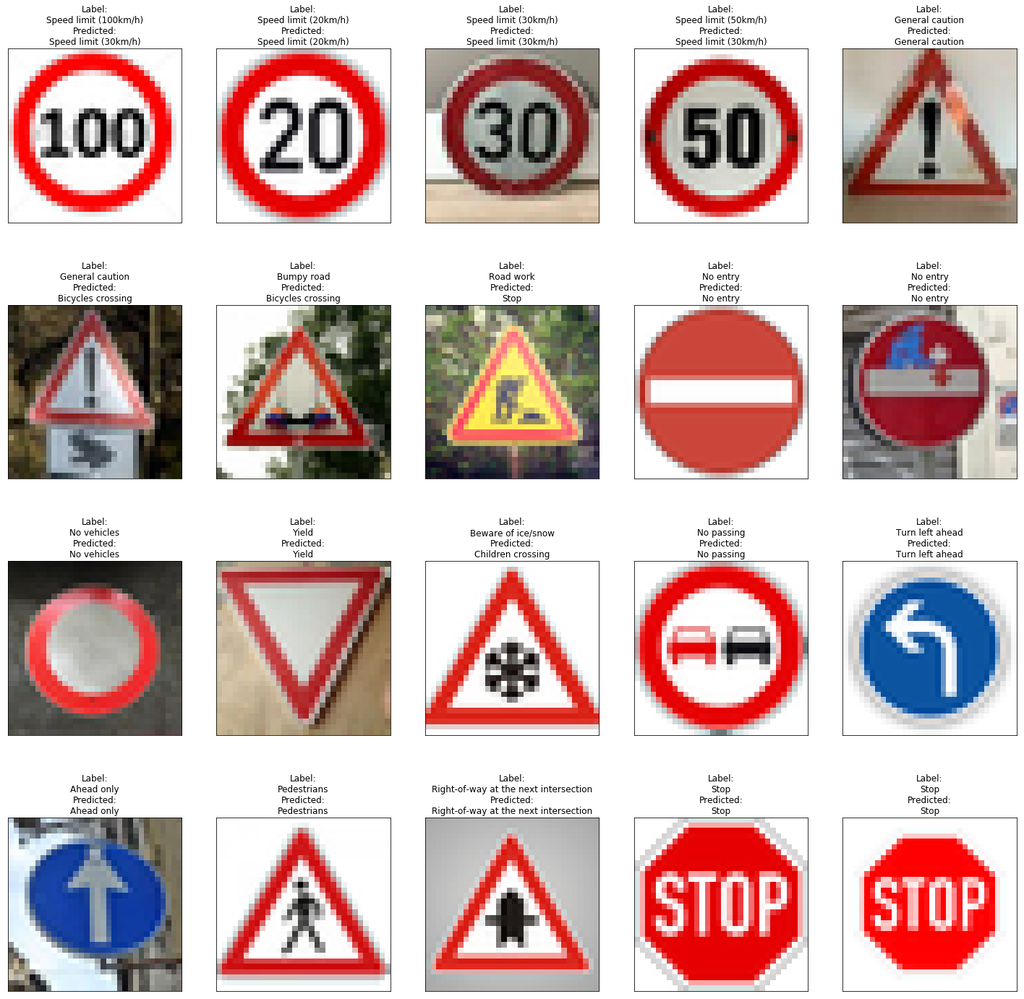

```python
i=0
f, axarr = plt.subplots(4, 5, figsize=(25, 25))
for file in os.listdir("webpictures"):
    image = Image.open("webpictures/" + file)

    image.thumbnail((32, 32), Image.LANCZOS) # resizes image in-place

    axarr[int(i/5), i%5].imshow(image)
    axarr[int(i/5), i%5].set_title("Label:\n" + signnames[y_test_own_images[i]] + "\nPredicted:\n" + signnames[y_est[i]])
    axarr[int(i/5), i%5].get_xaxis().set_visible(False)
    axarr[int(i/5), i%5].get_yaxis().set_visible(False)

    i += 1
```

### Output Top 5 Softmax Probabilities For Each Image Found on the Web

```python
with tf.Session() as sess:
    sess.run(tf.global_variables_initializer())
    saver.restore(sess, 'model/c3c3p_c3c3p_fc_fc_fc.ckpt')
    logits = sess.run(logits, feed_dict={x: X_test_own_images})
    result = sess.run(tf.nn.softmax(logits=logits))
    top5 = sess.run(tf.nn.top_k(result, k=5))
```

```
INFO:tensorflow:Restoring parameters from model/c3c3p_c3c3p_fc_fc_fc.ckpt
```

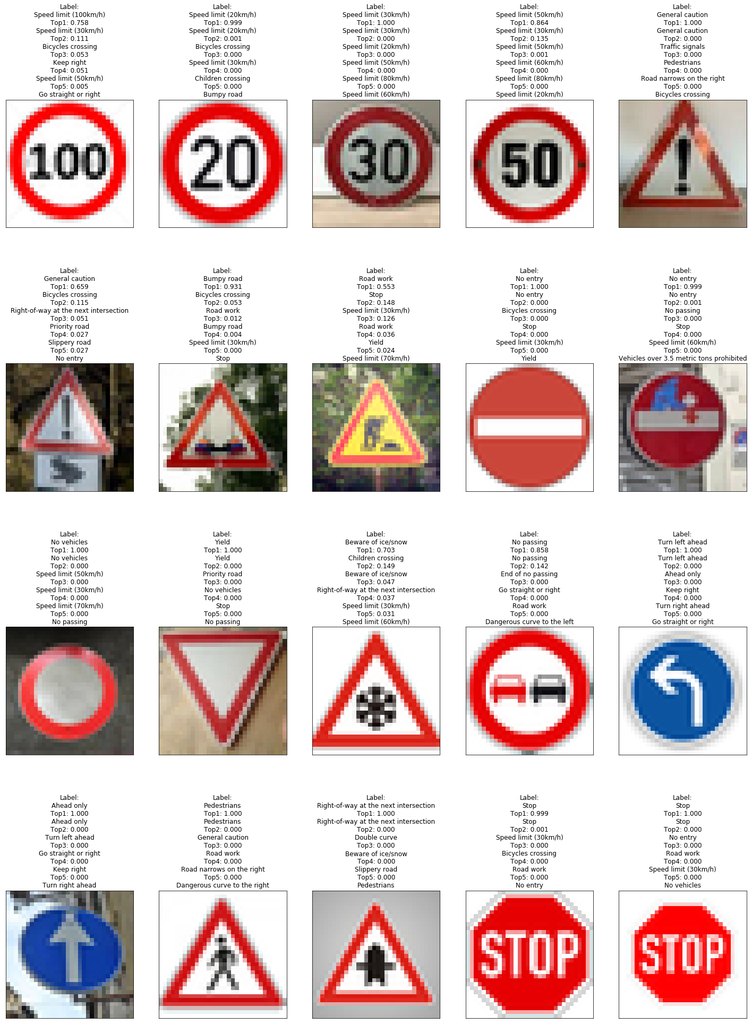

```python
i=0
f, axarr = plt.subplots(4, 5, figsize=(25, 35))
for file in os.listdir("webpictures"):
    image = Image.open("webpictures/" + file)

    image.thumbnail((32, 32), Image.LANCZOS) # resizes image in-place

    axarr[int(i/5), i%5].imshow(image)
    axarr[int(i/5), i%5].set_title("Label:\n" + signnames[y_test_own_images[i]] \
                                   + "\nTop1: {:.3f}".format(top5[0][i][0]) + "\n" + signnames[top5[1][i][0]] \
                                   + "\nTop2: {:.3f}".format(top5[0][i][1]) + "\n" + signnames[top5[1][i][1]] \
                                   + "\nTop3: {:.3f}".format(top5[0][i][2]) + "\n" + signnames[top5[1][i][2]] \
                                   + "\nTop4: {:.3f}".format(top5[0][i][3]) + "\n" + signnames[top5[1][i][3]] \
                                   + "\nTop5: {:.3f}".format(top5[0][i][4]) + "\n" + signnames[top5[1][i][4]])

    axarr[int(i/5), i%5].get_xaxis().set_visible(False)
    axarr[int(i/5), i%5].get_yaxis().set_visible(False)

    i += 1
```

### Project Writeup

Once you have completed the code implementation, document your results in a project writeup using this [template](https://github.com/udacity/CarND-Traffic-Sign-Classifier-Project/blob/master/writeup_template.md) as a guide. The writeup can be in a markdown or pdf file.